# Risk Factor Analysis

## Outcome Variable

**Outcome Variable:** ever_stunted

## Predictor Variables

**Intervention Variable:** hfoodsec

**Adjustment Set:**

- arm
- sex
- W_mage
- meducyrs
- feducyrs
- hhwealth_quart
- vagbrth
- W_nrooms
- W_nchldlt5
- brthmon
- W_parity
- impfloor
- impsan
- safeh20
- delta_sex
- delta_W_mage
- delta_meducyrs
- delta_feducyrs
- delta_hhwealth_quart
- delta_vagbrth
- delta_W_nrooms
- delta_W_nchldlt5
- delta_brthmon
- delta_W_parity
- delta_impfloor
- delta_impsan
- delta_safeh20

## Stratifying Variables

The analysis was stratified on these variable(s):

- agecat
- studyid
- country

## Data Summary

| agecat | studyid | country | hfoodsec | ever_stunted | n_cell | n |
| --- | --- | --- | --- | --- | --- | --- |
| 0-24 months | GMS-Nepal | NEPAL | Food Secure | 0 | 181 | 674 |
| 0-24 months | GMS-Nepal | NEPAL | Food Secure | 1 | 298 | 674 |
| 0-24 months | GMS-Nepal | NEPAL | Mildly Food Insecure | 0 | 38 | 674 |
| 0-24 months | GMS-Nepal | NEPAL | Mildly Food Insecure | 1 | 68 | 674 |
| 0-24 months | GMS-Nepal | NEPAL | Food Insecure | 0 | 26 | 674 |
| 0-24 months | GMS-Nepal | NEPAL | Food Insecure | 1 | 63 | 674 |
| 0-24 months | JiVitA-3 | BANGLADESH | Food Secure | 0 | 4441 | 17380 |
| 0-24 months | JiVitA-3 | BANGLADESH | Food Secure | 1 | 4258 | 17380 |
| 0-24 months | JiVitA-3 | BANGLADESH | Mildly Food Insecure | 0 | 2618 | 17380 |
| 0-24 months | JiVitA-3 | BANGLADESH | Mildly Food Insecure | 1 | 3167 | 17380 |
| 0-24 months | JiVitA-3 | BANGLADESH | Food Insecure | 0 | 1212 | 17380 |
| 0-24 months | JiVitA-3 | BANGLADESH | Food Insecure | 1 | 1684 | 17380 |
| 0-24 months | JiVitA-4 | BANGLADESH | Food Secure | 0 | 1143 | 5398 |
| 0-24 months | JiVitA-4 | BANGLADESH | Food Secure | 1 | 1606 | 5398 |
| 0-24 months | JiVitA-4 | BANGLADESH | Mildly Food Insecure | 0 | 812 | 5398 |
| 0-24 months | JiVitA-4 | BANGLADESH | Mildly Food Insecure | 1 | 1135 | 5398 |
| 0-24 months | JiVitA-4 | BANGLADESH | Food Insecure | 0 | 305 | 5398 |
| 0-24 months | JiVitA-4 | BANGLADESH | Food Insecure | 1 | 397 | 5398 |
| 0-24 months | MAL-ED | BANGLADESH | Food Secure | 0 | 61 | 194 |
| 0-24 months | MAL-ED | BANGLADESH | Food Secure | 1 | 100 | 194 |
| 0-24 months | MAL-ED | BANGLADESH | Mildly Food Insecure | 0 | 1 | 194 |
| 0-24 months | MAL-ED | BANGLADESH | Mildly Food Insecure | 1 | 3 | 194 |
| 0-24 months | MAL-ED | BANGLADESH | Food Insecure | 0 | 10 | 194 |
| 0-24 months | MAL-ED | BANGLADESH | Food Insecure | 1 | 19 | 194 |
| 0-24 months | MAL-ED | BRAZIL | Food Secure | 0 | 3 | 129 |
| 0-24 months | MAL-ED | BRAZIL | Food Secure | 1 | 0 | 129 |
| 0-24 months | MAL-ED | BRAZIL | Mildly Food Insecure | 0 | 7 | 129 |
| 0-24 months | MAL-ED | BRAZIL | Mildly Food Insecure | 1 | 4 | 129 |
| 0-24 months | MAL-ED | BRAZIL | Food Insecure | 0 | 84 | 129 |
| 0-24 months | MAL-ED | BRAZIL | Food Insecure | 1 | 31 | 129 |

[output cut: 168 more lines]

The following strata were considered:

- agecat: 0-24 months, studyid: GMS-Nepal, country: NEPAL
- agecat: 0-24 months, studyid: JiVitA-3, country: BANGLADESH
- agecat: 0-24 months, studyid: JiVitA-4, country: BANGLADESH
- agecat: 0-24 months, studyid: MAL-ED, country: BANGLADESH
- agecat: 0-24 months, studyid: MAL-ED, country: BRAZIL
- agecat: 0-24 months, studyid: MAL-ED, country: INDIA
- agecat: 0-24 months, studyid: MAL-ED, country: NEPAL
- agecat: 0-24 months, studyid: MAL-ED, country: PERU
- agecat: 0-24 months, studyid: MAL-ED, country: SOUTH AFRICA
- agecat: 0-24 months, studyid: NIH-Birth, country: BANGLADESH
- agecat: 0-24 months, studyid: NIH-Crypto, country: BANGLADESH
- agecat: 0-6 months, studyid: GMS-Nepal, country: NEPAL
- agecat: 0-6 months, studyid: JiVitA-3, country: BANGLADESH
- agecat: 0-6 months, studyid: JiVitA-4, country: BANGLADESH
- agecat: 0-6 months, studyid: MAL-ED, country: BANGLADESH
- agecat: 0-6 months, studyid: MAL-ED, country: BRAZIL
- agecat: 0-6 months, studyid: MAL-ED, country: INDIA
- agecat: 0-6 months, studyid: MAL-ED, country: NEPAL
- agecat: 0-6 months, studyid: MAL-ED, country: PERU
- agecat: 0-6 months, studyid: MAL-ED, country: SOUTH AFRICA
- agecat: 0-6 months, studyid: NIH-Birth, country: BANGLADESH
- agecat: 0-6 months, studyid: NIH-Crypto, country: BANGLADESH
- agecat: 6-24 months, studyid: GMS-Nepal, country: NEPAL
- agecat: 6-24 months, studyid: JiVitA-3, country: BANGLADESH
- agecat: 6-24 months, studyid: JiVitA-4, country: BANGLADESH
- agecat: 6-24 months, studyid: MAL-ED, country: BANGLADESH
- agecat: 6-24 months, studyid: MAL-ED, country: BRAZIL
- agecat: 6-24 months, studyid: MAL-ED, country: INDIA
- agecat: 6-24 months, studyid: MAL-ED, country: NEPAL
- agecat: 6-24 months, studyid: MAL-ED, country: PERU
- agecat: 6-24 months, studyid: MAL-ED, country: SOUTH AFRICA
- agecat: 6-24 months, studyid: NIH-Birth, country: BANGLADESH
- agecat: 6-24 months, studyid: NIH-Crypto, country: BANGLADESH

### Dropped Strata

Some strata were dropped due to rare outcomes:

- agecat: 0-24 months, studyid: MAL-ED, country: BANGLADESH
- agecat: 0-24 months, studyid: MAL-ED, country: BRAZIL
- agecat: 0-24 months, studyid: MAL-ED, country: INDIA
- agecat: 0-6 months, studyid: MAL-ED, country: BANGLADESH
- agecat: 0-6 months, studyid: MAL-ED, country: BRAZIL
- agecat: 0-6 months, studyid: MAL-ED, country: INDIA
- agecat: 0-6 months, studyid: MAL-ED, country: NEPAL
- agecat: 0-6 months, studyid: MAL-ED, country: SOUTH AFRICA
- agecat: 6-24 months, studyid: MAL-ED, country: BANGLADESH
- agecat: 6-24 months, studyid: MAL-ED, country: BRAZIL
- agecat: 6-24 months, studyid: MAL-ED, country: INDIA
- agecat: 6-24 months, studyid: MAL-ED, country: NEPAL

## Methods Detail

We’re interested in the causal parameters $E[Y_a]$ for all values of $a \in \mathcal{A}$. These parameters represent the mean outcome if, possibly contrary to fact, we intervened to set all units to have $A=a$. Under the randomization and positivity assumptions, these are identified by the statistical parameters $\psi_a=E_W[E_{Y|A,W}(Y|A=a,W)]$. In addition, we’re interested in the mean of $Y$, $E[Y]$ under no intervention (the observed mean). We will estimate these parameters by using SuperLearner to fit the relevant likelihood factors – $E_{Y|A,W}(Y|A=a,W)$ and $p(A=a|W)$, and then updating our likelihood fit using a joint TMLE.

For unadjusted analyses ($W=\{\}$), initial likelihoods were estimated using Lrnr_glm to estimate the simple $E(Y|A)$ and Lrnr_mean to estimate $p(A)$. For adjusted analyses, a small library containing Lrnr_glmnet, Lrnr_xgboost, and Lrnr_mean was used.

Having estimated these parameters, we will then use the delta method to estimate relative risks and attributable risks relative to a prespecified baseline level of $A$.

# Results Detail

## Results Plots

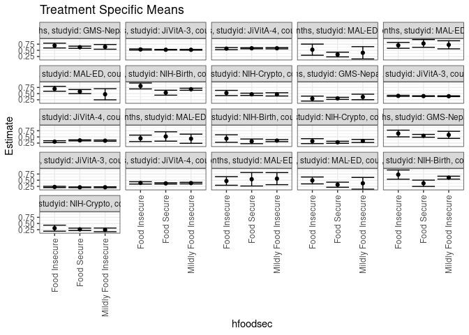

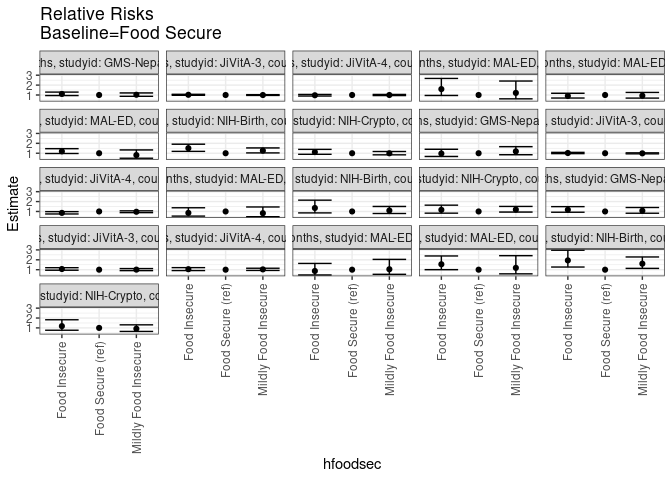

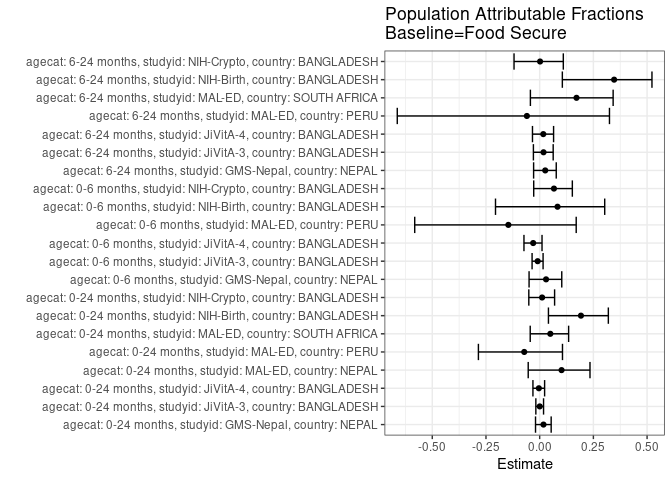

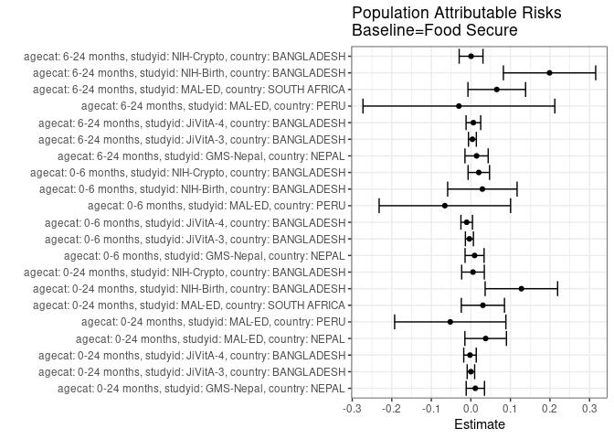

## Results Table

### Parameter: TSM

| agecat | studyid | country | intervention_level | baseline_level | estimate | ci_lower | ci_upper |
| --- | --- | --- | --- | --- | --- | --- | --- |
| 0-24 months | GMS-Nepal | NEPAL | Food Secure | NA | 0.6251971 | 0.5816137 | 0.6687805 |
| 0-24 months | GMS-Nepal | NEPAL | Mildly Food Insecure | NA | 0.6409220 | 0.5456654 | 0.7361787 |
| 0-24 months | GMS-Nepal | NEPAL | Food Insecure | NA | 0.6918234 | 0.5947851 | 0.7888617 |
| 0-24 months | JiVitA-3 | BANGLADESH | Food Secure | NA | 0.5239789 | 0.5110256 | 0.5369322 |
| 0-24 months | JiVitA-3 | BANGLADESH | Mildly Food Insecure | NA | 0.5220457 | 0.5058595 | 0.5382318 |
| 0-24 months | JiVitA-3 | BANGLADESH | Food Insecure | NA | 0.5348548 | 0.5115446 | 0.5581651 |
| 0-24 months | JiVitA-4 | BANGLADESH | Food Secure | NA | 0.5835651 | 0.5612713 | 0.6058589 |
| 0-24 months | JiVitA-4 | BANGLADESH | Mildly Food Insecure | NA | 0.5833284 | 0.5577798 | 0.6088771 |
| 0-24 months | JiVitA-4 | BANGLADESH | Food Insecure | NA | 0.5680240 | 0.5251220 | 0.6109259 |
| 0-24 months | MAL-ED | NEPAL | Food Secure | NA | 0.3297872 | 0.2343736 | 0.4252009 |
| 0-24 months | MAL-ED | NEPAL | Mildly Food Insecure | NA | 0.4000000 | 0.1511078 | 0.6488922 |
| 0-24 months | MAL-ED | NEPAL | Food Insecure | NA | 0.5263158 | 0.3009219 | 0.7517096 |
| 0-24 months | MAL-ED | PERU | Food Secure | NA | 0.7777778 | 0.6202642 | 0.9352913 |
| 0-24 months | MAL-ED | PERU | Mildly Food Insecure | NA | 0.7241379 | 0.5607440 | 0.8875319 |
| 0-24 months | MAL-ED | PERU | Food Insecure | NA | 0.7017544 | 0.5824599 | 0.8210489 |
| 0-24 months | MAL-ED | SOUTH AFRICA | Food Secure | NA | 0.5833333 | 0.4990488 | 0.6676179 |
| 0-24 months | MAL-ED | SOUTH AFRICA | Mildly Food Insecure | NA | 0.4736842 | 0.2486892 | 0.6986792 |
| 0-24 months | MAL-ED | SOUTH AFRICA | Food Insecure | NA | 0.6951220 | 0.5952672 | 0.7949767 |
| 0-24 months | NIH-Birth | BANGLADESH | Food Secure | NA | 0.5368421 | 0.4364916 | 0.6371926 |
| 0-24 months | NIH-Birth | BANGLADESH | Mildly Food Insecure | NA | 0.6768293 | 0.6354706 | 0.7181879 |
| 0-24 months | NIH-Birth | BANGLADESH | Food Insecure | NA | 0.8095238 | 0.6906725 | 0.9283752 |
| 0-24 months | NIH-Crypto | BANGLADESH | Food Secure | NA | 0.4721978 | 0.4263493 | 0.5180462 |
| 0-24 months | NIH-Crypto | BANGLADESH | Mildly Food Insecure | NA | 0.4693459 | 0.4038944 | 0.5347973 |
| 0-24 months | NIH-Crypto | BANGLADESH | Food Insecure | NA | 0.5262521 | 0.4213885 | 0.6311156 |
| 0-6 months | GMS-Nepal | NEPAL | Food Secure | NA | 0.3066437 | 0.2645681 | 0.3487193 |
| 0-6 months | GMS-Nepal | NEPAL | Mildly Food Insecure | NA | 0.3643758 | 0.2527659 | 0.4759856 |
| 0-6 months | GMS-Nepal | NEPAL | Food Insecure | NA | 0.2977437 | 0.1966954 | 0.3987920 |
| 0-6 months | JiVitA-3 | BANGLADESH | Food Secure | NA | 0.3992408 | 0.3858901 | 0.4125915 |
| 0-6 months | JiVitA-3 | BANGLADESH | Mildly Food Insecure | NA | 0.3943155 | 0.3784604 | 0.4101706 |
| 0-6 months | JiVitA-3 | BANGLADESH | Food Insecure | NA | 0.4079387 | 0.3851033 | 0.4307742 |
| 0-6 months | JiVitA-4 | BANGLADESH | Food Secure | NA | 0.3589331 | 0.3377474 | 0.3801187 |
| 0-6 months | JiVitA-4 | BANGLADESH | Mildly Food Insecure | NA | 0.3476149 | 0.3224895 | 0.3727403 |
| 0-6 months | JiVitA-4 | BANGLADESH | Food Insecure | NA | 0.3071832 | 0.2695143 | 0.3448521 |
| 0-6 months | MAL-ED | PERU | Food Secure | NA | 0.5171178 | 0.3270607 | 0.7071750 |
| 0-6 months | MAL-ED | PERU | Mildly Food Insecure | NA | 0.4264148 | 0.2406572 | 0.6121723 |
| 0-6 months | MAL-ED | PERU | Food Insecure | NA | 0.4416829 | 0.3111655 | 0.5722003 |
| 0-6 months | NIH-Birth | BANGLADESH | Food Secure | NA | 0.3206900 | 0.2258722 | 0.4155078 |
| 0-6 months | NIH-Birth | BANGLADESH | Mildly Food Insecure | NA | 0.3505035 | 0.3082518 | 0.3927552 |
| 0-6 months | NIH-Birth | BANGLADESH | Food Insecure | NA | 0.4334496 | 0.2807087 | 0.5861905 |
| 0-6 months | NIH-Crypto | BANGLADESH | Food Secure | NA | 0.2820353 | 0.2405316 | 0.3235390 |
| 0-6 months | NIH-Crypto | BANGLADESH | Mildly Food Insecure | NA | 0.3356674 | 0.2728951 | 0.3984398 |
| 0-6 months | NIH-Crypto | BANGLADESH | Food Insecure | NA | 0.3282995 | 0.2278764 | 0.4287226 |
| 6-24 months | GMS-Nepal | NEPAL | Food Secure | NA | 0.5437074 | 0.4858990 | 0.6015158 |
| 6-24 months | GMS-Nepal | NEPAL | Mildly Food Insecure | NA | 0.5834294 | 0.4401328 | 0.7267259 |
| 6-24 months | GMS-Nepal | NEPAL | Food Insecure | NA | 0.6374394 | 0.5014450 | 0.7734337 |
| 6-24 months | JiVitA-3 | BANGLADESH | Food Secure | NA | 0.2122326 | 0.1990018 | 0.2254633 |
| 6-24 months | JiVitA-3 | BANGLADESH | Mildly Food Insecure | NA | 0.2135776 | 0.1960113 | 0.2311439 |
| 6-24 months | JiVitA-3 | BANGLADESH | Food Insecure | NA | 0.2266074 | 0.2019338 | 0.2512811 |
| 6-24 months | JiVitA-4 | BANGLADESH | Food Secure | NA | 0.3709683 | 0.3449607 | 0.3969760 |
| 6-24 months | JiVitA-4 | BANGLADESH | Mildly Food Insecure | NA | 0.3821268 | 0.3510035 | 0.4132500 |
| 6-24 months | JiVitA-4 | BANGLADESH | Food Insecure | NA | 0.3897717 | 0.3419117 | 0.4376318 |
| 6-24 months | MAL-ED | PERU | Food Secure | NA | 0.5384615 | 0.2652198 | 0.8117033 |
| 6-24 months | MAL-ED | PERU | Mildly Food Insecure | NA | 0.5625000 | 0.3174088 | 0.8075912 |
| 6-24 months | MAL-ED | PERU | Food Insecure | NA | 0.4687500 | 0.2944158 | 0.6430842 |
| 6-24 months | MAL-ED | SOUTH AFRICA | Food Secure | NA | 0.3164557 | 0.2135386 | 0.4193728 |
| 6-24 months | MAL-ED | SOUTH AFRICA | Mildly Food Insecure | NA | 0.3750000 | 0.1369561 | 0.6130439 |
| 6-24 months | MAL-ED | SOUTH AFRICA | Food Insecure | NA | 0.4897959 | 0.3493391 | 0.6302527 |
| 6-24 months | NIH-Birth | BANGLADESH | Food Secure | NA | 0.3750000 | 0.2480186 | 0.5019814 |
| 6-24 months | NIH-Birth | BANGLADESH | Mildly Food Insecure | NA | 0.6029963 | 0.5442233 | 0.6617692 |
| 6-24 months | NIH-Birth | BANGLADESH | Food Insecure | NA | 0.7272727 | 0.5409010 | 0.9136444 |
| 6-24 months | NIH-Crypto | BANGLADESH | Food Secure | NA | 0.2623502 | 0.2136572 | 0.3110431 |
| 6-24 months | NIH-Crypto | BANGLADESH | Mildly Food Insecure | NA | 0.2411886 | 0.1678423 | 0.3145349 |
| 6-24 months | NIH-Crypto | BANGLADESH | Food Insecure | NA | 0.3098621 | 0.1880826 | 0.4316415 |

### Parameter: E(Y)

| agecat | studyid | country | intervention_level | baseline_level | estimate | ci_lower | ci_upper |
| --- | --- | --- | --- | --- | --- | --- | --- |
| 0-24 months | GMS-Nepal | NEPAL | NA | NA | 0.6364985 | 0.6001579 | 0.6728391 |
| 0-24 months | JiVitA-3 | BANGLADESH | NA | NA | 0.5241082 | 0.5145463 | 0.5336700 |
| 0-24 months | JiVitA-4 | BANGLADESH | NA | NA | 0.5813264 | 0.5653125 | 0.5973403 |
| 0-24 months | MAL-ED | NEPAL | NA | NA | 0.3671875 | 0.2833521 | 0.4510229 |
| 0-24 months | MAL-ED | PERU | NA | NA | 0.7256637 | 0.6430317 | 0.8082957 |
| 0-24 months | MAL-ED | SOUTH AFRICA | NA | NA | 0.6137339 | 0.5510815 | 0.6763863 |
| 0-24 months | NIH-Birth | BANGLADESH | NA | NA | 0.6645469 | 0.6276196 | 0.7014742 |
| 0-24 months | NIH-Crypto | BANGLADESH | NA | NA | 0.4775726 | 0.4419904 | 0.5131548 |
| 0-6 months | GMS-Nepal | NEPAL | NA | NA | 0.3160237 | 0.2808984 | 0.3511491 |
| 0-6 months | JiVitA-3 | BANGLADESH | NA | NA | 0.3955073 | 0.3867171 | 0.4042976 |
| 0-6 months | JiVitA-4 | BANGLADESH | NA | NA | 0.3483896 | 0.3331073 | 0.3636720 |
| 0-6 months | MAL-ED | PERU | NA | NA | 0.4513274 | 0.3591676 | 0.5434872 |
| 0-6 months | NIH-Birth | BANGLADESH | NA | NA | 0.3497615 | 0.3124631 | 0.3870600 |
| 0-6 months | NIH-Crypto | BANGLADESH | NA | NA | 0.3021108 | 0.2694011 | 0.3348205 |
| 6-24 months | GMS-Nepal | NEPAL | NA | NA | 0.5581395 | 0.5085981 | 0.6076809 |
| 6-24 months | JiVitA-3 | BANGLADESH | NA | NA | 0.2161025 | 0.2066983 | 0.2255067 |
| 6-24 months | JiVitA-4 | BANGLADESH | NA | NA | 0.3773167 | 0.3586399 | 0.3959936 |
| 6-24 months | MAL-ED | PERU | NA | NA | 0.5081967 | 0.3816986 | 0.6346949 |
| 6-24 months | MAL-ED | SOUTH AFRICA | NA | NA | 0.3819444 | 0.3023113 | 0.4615776 |
| 6-24 months | NIH-Birth | BANGLADESH | NA | NA | 0.5739130 | 0.5216565 | 0.6261696 |
| 6-24 months | NIH-Crypto | BANGLADESH | NA | NA | 0.2628458 | 0.2244546 | 0.3012371 |

### Parameter: RR

| agecat | studyid | country | intervention_level | baseline_level | estimate | ci_lower | ci_upper |
| --- | --- | --- | --- | --- | --- | --- | --- |
| 0-24 months | GMS-Nepal | NEPAL | Food Secure | Food Secure | 1.0000000 | 1.0000000 | 1.0000000 |
| 0-24 months | GMS-Nepal | NEPAL | Mildly Food Insecure | Food Secure | 1.0251520 | 0.8699457 | 1.2080486 |
| 0-24 months | GMS-Nepal | NEPAL | Food Insecure | Food Secure | 1.1065686 | 0.9460810 | 1.2942803 |
| 0-24 months | JiVitA-3 | BANGLADESH | Food Secure | Food Secure | 1.0000000 | 1.0000000 | 1.0000000 |
| 0-24 months | JiVitA-3 | BANGLADESH | Mildly Food Insecure | Food Secure | 0.9963105 | 0.9607517 | 1.0331853 |
| 0-24 months | JiVitA-3 | BANGLADESH | Food Insecure | Food Secure | 1.0207565 | 0.9737446 | 1.0700381 |
| 0-24 months | JiVitA-4 | BANGLADESH | Food Secure | Food Secure | 1.0000000 | 1.0000000 | 1.0000000 |
| 0-24 months | JiVitA-4 | BANGLADESH | Mildly Food Insecure | Food Secure | 0.9995944 | 0.9430553 | 1.0595233 |
| 0-24 months | JiVitA-4 | BANGLADESH | Food Insecure | Food Secure | 0.9733687 | 0.8943554 | 1.0593626 |
| 0-24 months | MAL-ED | NEPAL | Food Secure | Food Secure | 1.0000000 | 1.0000000 | 1.0000000 |
| 0-24 months | MAL-ED | NEPAL | Mildly Food Insecure | Food Secure | 1.2129032 | 0.6106769 | 2.4090222 |
| 0-24 months | MAL-ED | NEPAL | Food Insecure | Food Secure | 1.5959253 | 0.9518332 | 2.6758654 |
| 0-24 months | MAL-ED | PERU | Food Secure | Food Secure | 1.0000000 | 1.0000000 | 1.0000000 |
| 0-24 months | MAL-ED | PERU | Mildly Food Insecure | Food Secure | 0.9310345 | 0.6875281 | 1.2607852 |
| 0-24 months | MAL-ED | PERU | Food Insecure | Food Secure | 0.9022556 | 0.6926259 | 1.1753317 |
| 0-24 months | MAL-ED | SOUTH AFRICA | Food Secure | Food Secure | 1.0000000 | 1.0000000 | 1.0000000 |
| 0-24 months | MAL-ED | SOUTH AFRICA | Mildly Food Insecure | Food Secure | 0.8120301 | 0.4942582 | 1.3341060 |
| 0-24 months | MAL-ED | SOUTH AFRICA | Food Insecure | Food Secure | 1.1916376 | 0.9719830 | 1.4609312 |
| 0-24 months | NIH-Birth | BANGLADESH | Food Secure | Food Secure | 1.0000000 | 1.0000000 | 1.0000000 |
| 0-24 months | NIH-Birth | BANGLADESH | Mildly Food Insecure | Food Secure | 1.2607604 | 1.0356748 | 1.5347643 |
| 0-24 months | NIH-Birth | BANGLADESH | Food Insecure | Food Secure | 1.5079365 | 1.1889272 | 1.9125414 |
| 0-24 months | NIH-Crypto | BANGLADESH | Food Secure | Food Secure | 1.0000000 | 1.0000000 | 1.0000000 |
| 0-24 months | NIH-Crypto | BANGLADESH | Mildly Food Insecure | Food Secure | 0.9939603 | 0.8398062 | 1.1764109 |
| 0-24 months | NIH-Crypto | BANGLADESH | Food Insecure | Food Secure | 1.1144738 | 0.8939358 | 1.3894197 |
| 0-6 months | GMS-Nepal | NEPAL | Food Secure | Food Secure | 1.0000000 | 1.0000000 | 1.0000000 |
| 0-6 months | GMS-Nepal | NEPAL | Mildly Food Insecure | Food Secure | 1.1882709 | 0.8494836 | 1.6621717 |
| 0-6 months | GMS-Nepal | NEPAL | Food Insecure | Food Secure | 0.9709762 | 0.6734735 | 1.3998990 |
| 0-6 months | JiVitA-3 | BANGLADESH | Food Secure | Food Secure | 1.0000000 | 1.0000000 | 1.0000000 |
| 0-6 months | JiVitA-3 | BANGLADESH | Mildly Food Insecure | Food Secure | 0.9876634 | 0.9386252 | 1.0392636 |
| 0-6 months | JiVitA-3 | BANGLADESH | Food Insecure | Food Secure | 1.0217863 | 0.9588220 | 1.0888853 |
| 0-6 months | JiVitA-4 | BANGLADESH | Food Secure | Food Secure | 1.0000000 | 1.0000000 | 1.0000000 |
| 0-6 months | JiVitA-4 | BANGLADESH | Mildly Food Insecure | Food Secure | 0.9684672 | 0.8835268 | 1.0615736 |
| 0-6 months | JiVitA-4 | BANGLADESH | Food Insecure | Food Secure | 0.8558230 | 0.7467393 | 0.9808415 |
| 0-6 months | MAL-ED | PERU | Food Secure | Food Secure | 1.0000000 | 1.0000000 | 1.0000000 |
| 0-6 months | MAL-ED | PERU | Mildly Food Insecure | Food Secure | 0.8245989 | 0.4676775 | 1.4539151 |
| 0-6 months | MAL-ED | PERU | Food Insecure | Food Secure | 0.8541244 | 0.5311929 | 1.3733775 |
| 0-6 months | NIH-Birth | BANGLADESH | Food Secure | Food Secure | 1.0000000 | 1.0000000 | 1.0000000 |
| 0-6 months | NIH-Birth | BANGLADESH | Mildly Food Insecure | Food Secure | 1.0929668 | 0.7940441 | 1.5044208 |
| 0-6 months | NIH-Birth | BANGLADESH | Food Insecure | Food Secure | 1.3516156 | 0.8532988 | 2.1409438 |
| 0-6 months | NIH-Crypto | BANGLADESH | Food Secure | Food Secure | 1.0000000 | 1.0000000 | 1.0000000 |
| 0-6 months | NIH-Crypto | BANGLADESH | Mildly Food Insecure | Food Secure | 1.1901612 | 0.9381226 | 1.5099130 |
| 0-6 months | NIH-Crypto | BANGLADESH | Food Insecure | Food Secure | 1.1640370 | 0.8288834 | 1.6347078 |
| 6-24 months | GMS-Nepal | NEPAL | Food Secure | Food Secure | 1.0000000 | 1.0000000 | 1.0000000 |
| 6-24 months | GMS-Nepal | NEPAL | Mildly Food Insecure | Food Secure | 1.0730576 | 0.8213464 | 1.4019085 |
| 6-24 months | GMS-Nepal | NEPAL | Food Insecure | Food Secure | 1.1723941 | 0.9233429 | 1.4886213 |
| 6-24 months | JiVitA-3 | BANGLADESH | Food Secure | Food Secure | 1.0000000 | 1.0000000 | 1.0000000 |
| 6-24 months | JiVitA-3 | BANGLADESH | Mildly Food Insecure | Food Secure | 1.0063375 | 0.9093653 | 1.1136506 |
| 6-24 months | JiVitA-3 | BANGLADESH | Food Insecure | Food Secure | 1.0677317 | 0.9491234 | 1.2011621 |
| 6-24 months | JiVitA-4 | BANGLADESH | Food Secure | Food Secure | 1.0000000 | 1.0000000 | 1.0000000 |
| 6-24 months | JiVitA-4 | BANGLADESH | Mildly Food Insecure | Food Secure | 1.0300792 | 0.9249647 | 1.1471390 |
| 6-24 months | JiVitA-4 | BANGLADESH | Food Insecure | Food Secure | 1.0506873 | 0.9130433 | 1.2090817 |
| 6-24 months | MAL-ED | PERU | Food Secure | Food Secure | 1.0000000 | 1.0000000 | 1.0000000 |
| 6-24 months | MAL-ED | PERU | Mildly Food Insecure | Food Secure | 1.0446429 | 0.5351702 | 2.0391245 |
| 6-24 months | MAL-ED | PERU | Food Insecure | Food Secure | 0.8705357 | 0.4640367 | 1.6331303 |
| 6-24 months | MAL-ED | SOUTH AFRICA | Food Secure | Food Secure | 1.0000000 | 1.0000000 | 1.0000000 |
| 6-24 months | MAL-ED | SOUTH AFRICA | Mildly Food Insecure | Food Secure | 1.1850000 | 0.5807115 | 2.4181113 |
| 6-24 months | MAL-ED | SOUTH AFRICA | Food Insecure | Food Secure | 1.5477551 | 1.0032193 | 2.3878586 |
| 6-24 months | NIH-Birth | BANGLADESH | Food Secure | Food Secure | 1.0000000 | 1.0000000 | 1.0000000 |
| 6-24 months | NIH-Birth | BANGLADESH | Mildly Food Insecure | Food Secure | 1.6079900 | 1.1304540 | 2.2872508 |
| 6-24 months | NIH-Birth | BANGLADESH | Food Insecure | Food Secure | 1.9393939 | 1.2683556 | 2.9654529 |
| 6-24 months | NIH-Crypto | BANGLADESH | Food Secure | Food Secure | 1.0000000 | 1.0000000 | 1.0000000 |
| 6-24 months | NIH-Crypto | BANGLADESH | Mildly Food Insecure | Food Secure | 0.9193385 | 0.6440980 | 1.3121967 |
| 6-24 months | NIH-Crypto | BANGLADESH | Food Insecure | Food Secure | 1.1811011 | 0.7649701 | 1.8236005 |

### Parameter: PAR

| agecat | studyid | country | intervention_level | baseline_level | estimate | ci_lower | ci_upper |
| --- | --- | --- | --- | --- | --- | --- | --- |
| 0-24 months | GMS-Nepal | NEPAL | Food Secure | NA | 0.0113014 | -0.0118356 | 0.0344385 |
| 0-24 months | JiVitA-3 | BANGLADESH | Food Secure | NA | 0.0001293 | -0.0092776 | 0.0095362 |
| 0-24 months | JiVitA-4 | BANGLADESH | Food Secure | NA | -0.0022387 | -0.0180340 | 0.0135566 |
| 0-24 months | MAL-ED | NEPAL | Food Secure | NA | 0.0374003 | -0.0151449 | 0.0899454 |
| 0-24 months | MAL-ED | PERU | Food Secure | NA | -0.0521141 | -0.1927633 | 0.0885352 |
| 0-24 months | MAL-ED | SOUTH AFRICA | Food Secure | NA | 0.0304006 | -0.0241903 | 0.0849915 |
| 0-24 months | NIH-Birth | BANGLADESH | Food Secure | NA | 0.1277048 | 0.0360971 | 0.2193125 |
| 0-24 months | NIH-Crypto | BANGLADESH | Food Secure | NA | 0.0053748 | -0.0232663 | 0.0340159 |
| 0-6 months | GMS-Nepal | NEPAL | Food Secure | NA | 0.0093801 | -0.0146398 | 0.0333999 |
| 0-6 months | JiVitA-3 | BANGLADESH | Food Secure | NA | -0.0037335 | -0.0138583 | 0.0063914 |
| 0-6 months | JiVitA-4 | BANGLADESH | Food Secure | NA | -0.0105435 | -0.0251794 | 0.0040925 |
| 0-6 months | MAL-ED | PERU | Food Secure | NA | -0.0657904 | -0.2319931 | 0.1004124 |
| 0-6 months | NIH-Birth | BANGLADESH | Food Secure | NA | 0.0290715 | -0.0587271 | 0.1168702 |
| 0-6 months | NIH-Crypto | BANGLADESH | Food Secure | NA | 0.0200755 | -0.0070584 | 0.0472095 |
| 6-24 months | GMS-Nepal | NEPAL | Food Secure | NA | 0.0144321 | -0.0149243 | 0.0437885 |
| 6-24 months | JiVitA-3 | BANGLADESH | Food Secure | NA | 0.0038699 | -0.0060866 | 0.0138264 |
| 6-24 months | JiVitA-4 | BANGLADESH | Food Secure | NA | 0.0063484 | -0.0121853 | 0.0248821 |
| 6-24 months | MAL-ED | PERU | Food Secure | NA | -0.0302648 | -0.2728345 | 0.2123049 |
| 6-24 months | MAL-ED | SOUTH AFRICA | Food Secure | NA | 0.0654887 | -0.0073924 | 0.1383699 |
| 6-24 months | NIH-Birth | BANGLADESH | Food Secure | NA | 0.1989130 | 0.0822062 | 0.3156198 |
| 6-24 months | NIH-Crypto | BANGLADESH | Food Secure | NA | 0.0004957 | -0.0295827 | 0.0305741 |

### Parameter: PAF

| agecat | studyid | country | intervention_level | baseline_level | estimate | ci_lower | ci_upper |
| --- | --- | --- | --- | --- | --- | --- | --- |
| 0-24 months | GMS-Nepal | NEPAL | Food Secure | NA | 0.0177556 | -0.0193178 | 0.0534807 |
| 0-24 months | JiVitA-3 | BANGLADESH | Food Secure | NA | 0.0002467 | -0.0178634 | 0.0180346 |
| 0-24 months | JiVitA-4 | BANGLADESH | Food Secure | NA | -0.0038510 | -0.0313953 | 0.0229577 |
| 0-24 months | MAL-ED | NEPAL | Food Secure | NA | 0.1018560 | -0.0533699 | 0.2342077 |
| 0-24 months | MAL-ED | PERU | Food Secure | NA | -0.0718157 | -0.2852318 | 0.1061621 |
| 0-24 months | MAL-ED | SOUTH AFRICA | Food Secure | NA | 0.0495338 | -0.0440285 | 0.1347113 |
| 0-24 months | NIH-Birth | BANGLADESH | Food Secure | NA | 0.1921682 | 0.0407818 | 0.3196624 |
| 0-24 months | NIH-Crypto | BANGLADESH | Food Secure | NA | 0.0112544 | -0.0505871 | 0.0694556 |
| 0-6 months | GMS-Nepal | NEPAL | Food Secure | NA | 0.0296815 | -0.0493731 | 0.1027805 |
| 0-6 months | JiVitA-3 | BANGLADESH | Food Secure | NA | -0.0094397 | -0.0353694 | 0.0158406 |
| 0-6 months | JiVitA-4 | BANGLADESH | Food Secure | NA | -0.0302634 | -0.0731605 | 0.0109190 |
| 0-6 months | MAL-ED | PERU | Food Secure | NA | -0.1457708 | -0.5817373 | 0.1700323 |
| 0-6 months | NIH-Birth | BANGLADESH | Food Secure | NA | 0.0831181 | -0.2056429 | 0.3027186 |
| 0-6 months | NIH-Crypto | BANGLADESH | Food Secure | NA | 0.0664509 | -0.0277701 | 0.1520341 |
| 6-24 months | GMS-Nepal | NEPAL | Food Secure | NA | 0.0258575 | -0.0282594 | 0.0771263 |
| 6-24 months | JiVitA-3 | BANGLADESH | Food Secure | NA | 0.0179079 | -0.0292153 | 0.0628734 |
| 6-24 months | JiVitA-4 | BANGLADESH | Food Secure | NA | 0.0168251 | -0.0335296 | 0.0647265 |
| 6-24 months | MAL-ED | PERU | Food Secure | NA | -0.0595533 | -0.6629489 | 0.3249021 |
| 6-24 months | MAL-ED | SOUTH AFRICA | Food Secure | NA | 0.1714614 | -0.0432176 | 0.3419627 |
| 6-24 months | NIH-Birth | BANGLADESH | Food Secure | NA | 0.3465909 | 0.1055065 | 0.5226981 |
| 6-24 months | NIH-Crypto | BANGLADESH | Food Secure | NA | 0.0018859 | -0.1193652 | 0.1100029 |